# HUGEN 2072 Project 3

## Part 2 - Principle Components of Ancestry

You have been provided with pre-calculated principal components of ancestry in `p3_pca.RData`. This file contains two data objects: `mypcair` the output from pcair and `pca` a data frame with 32 PCAs and scanID.

```r
# load PCA object
load(paste0(my_folder, "p3_pca.RData"), verbose = TRUE)
```

```
## Loading objects:
##   pca
##   mypcair
```

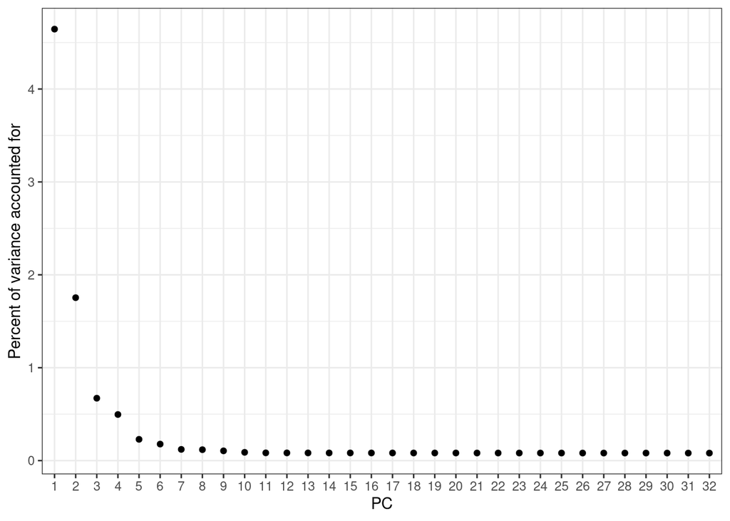

```r
# make scree plot
dat <- data.frame(pc=1:32, varprop=mypcair$varprop[1:32])
ggplot(dat, aes(x=factor(pc), y=100*varprop)) +
  geom_point() + theme_bw() +
  xlab("PC") + ylab("Percent of variance accounted for")
```

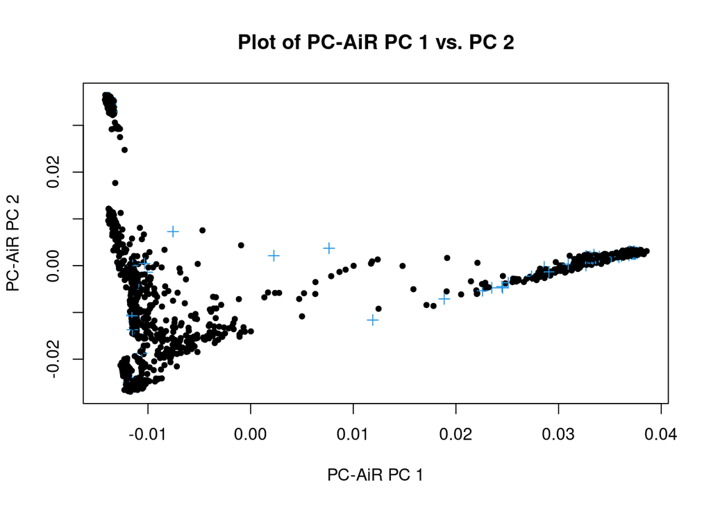

```r
# make exploratory plots
plot(mypcair) # PC1 and PC2
```

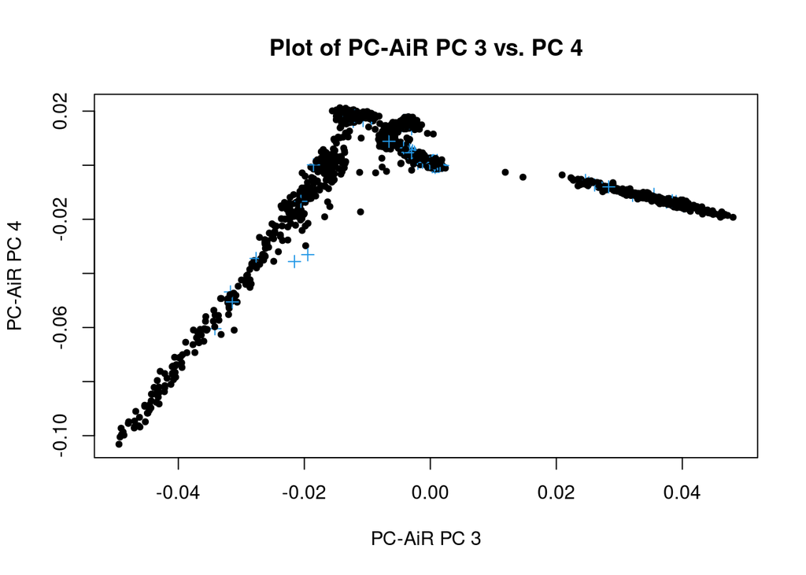

```r
plot(mypcair, vx = 3, vy =  4) # PC3 and PC4
```

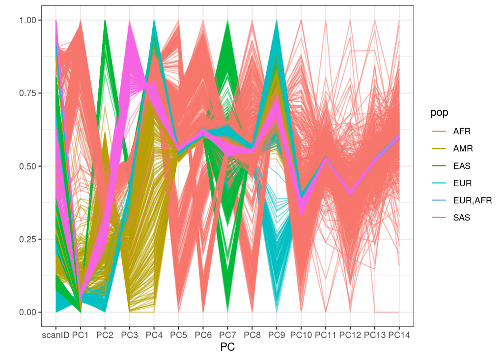

```r
# merge with sample.info to get pop code
pca <- left_join(pca, pData(sample.info), by="scanID")

# make parallel coordinates plot colored by pop code
ggparcoord(pca, columns=1:15, groupColumn="pop", alphaLines=0.5, scale="uniminmax") +
    guides(colour=guide_legend(override.aes=list(alpha=1, size=2))) +
    theme_bw() + xlab("PC") + ylab("")
```

```r
# decide how many PCAs to include in the GWAS
# add the PCA values to the scan annotation file to include them in the GWAS
# (change 32 to your selected number)
sample.info.pcs <- pca %>% select(scanID, sex, pop, height, PC1:PC4)
sample.info.pcs <- ScanAnnotationDataFrame(sample.info.pcs)
sample.info.pcs
```

```
## An object of class 'ScanAnnotationDataFrame'
##   scans: 1 2 ... 2548 (2548 total)
##   varLabels: scanID sex ... PC4 (8 total)
##   varMetadata: labelDescription
```

## Part 2 - Report

How many principal components of ancestry will you include as covariates in the GWAS? Why did you choose this number?

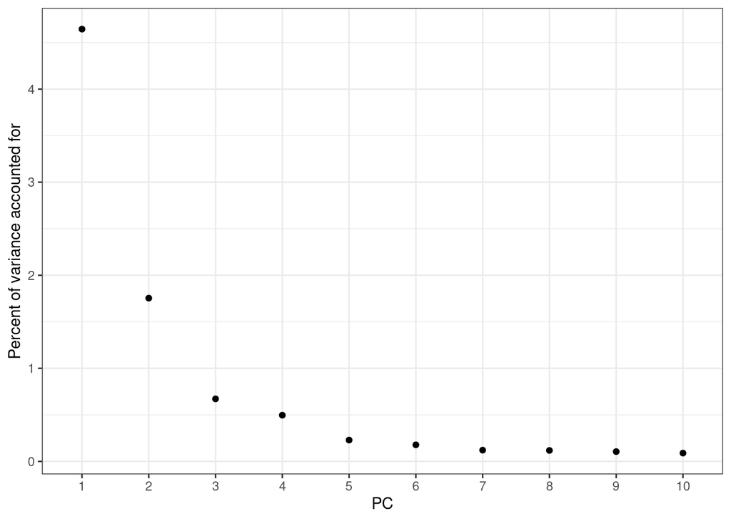

```r
# Your code goes here
#Part2 Qn1 : How many principal components of ancestry will you include as covariates in the GWAS? Why did you choose this number?
#Ans: I chose 4 pcs since in the diagram below we can see that there are major difference in slope till 4 and from 5 it is very straight.

dat <- data.frame(pc=1:10, varprop=mypcair$varprop[1:10])
ggplot(dat, aes(x=factor(pc), y=100*varprop)) +
  geom_point() + theme_bw() +
  xlab("PC") + ylab("Percent of variance accounted for")
```

## Part 3 - Null Model

PC-Relate was already run and the results are stored in `p3_grm.RData`. This file contains a genetic relatedness matrix (called `GRM`) and the results from pc-relate `mypcrelate`.

Create a kinship plot to examine relatedness among the sample.

```r
# Load in pc-relate results
load(paste0(my_folder, "p3_grm.RData"), verbose = TRUE)
```

```
## Loading objects:
##   mypcrelate
##   GRM
```

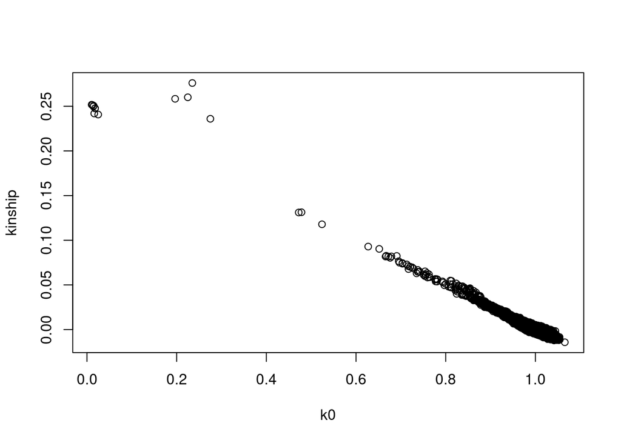

```r
# Make kinship plot
plot(mypcrelate$kinBtwn$k0, mypcrelate$kinBtwn$kin, xlab="k0", ylab="kinship")
```

Decide on a null model to use for a GWAS of height for this sample. You will be guided to think about specific aspects for these filters in the reporting section below.

Run the null model in the chunk below. **You will need to supply the code for running the null model.**

```r
# run the null model here (write code to do so)
null_model <- fitNullModel(sample.info.pcs,
                               outcome = "height",
                               covars = c("sex", "pop", "PC1","PC2","PC3","PC4"),
                               cov.mat = GRM,
                               family = "gaussian",
                               sample.id = NULL,
                               two.stage = FALSE)
```

```
## Computing Variance Component Estimates...
```

```
## Sigma^2_A     log-lik     RSS
```

```
## [1]    39.7205964    39.7205964 -7460.2640335     0.2616999
## [1]    17.3238010    34.0709042 -7460.1138307     0.4043122
## [1]     8.2939618    24.1643181 -7460.0917436     0.6400924
## [1]     3.151189    11.055898 -7460.092922     1.462322
## [1]     4.354694    14.344303 -7460.091862     1.111056
## [1]     4.978795    15.589514 -7460.091483     1.010092
## [1]     5.086388    15.687508 -7460.091458     1.000100
```

## Part 3 - Report

Do you think you should account for relatedness with a genetic relatedness matrix?

What type of model should be used for a GWAS of height (linear or logistic)?

Does the height phenotype appear to follow a normal distribution closely enough, or do you think we should use an inverse normal transformed phenotype here? Explain.

What covariates are included in the null model? (Hint: think back to your findings in part 0 and part 2.)

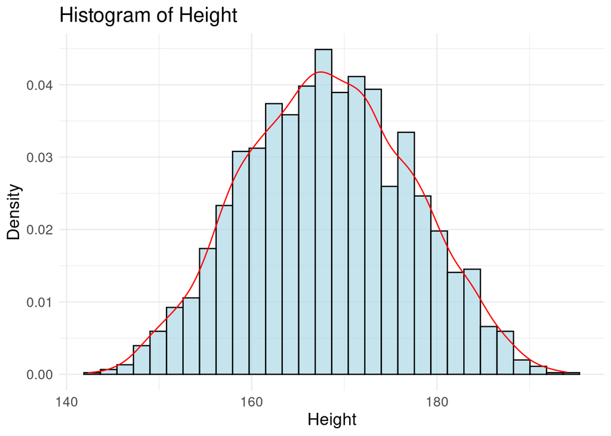

```r
# Your code goes here
#Part3 Qn1 : Do you think you should account for relatedness with a genetic relatedness matrix?
#Ans : Yes, I think we should include relatedness with GRM.

#Part3 Qn2 : What type of model should be used for a GWAS of height (linear or logistic)?
#Ans : linear model should be used since height phenotype is continuous trait. A logistic model is more useful when we want binary outcome(Eg: Affected or Not)

#Part3 Qn3 : Does the height phenotype appear to follow a normal distribution closely enough, or do you think we should use an inverse normal transformed phenotype here? Explain.
#Ans : Based on the histogram and Q-Q plots. Height phenotype appears to follow normal distribution and therefore no need to use an inverse normal transformation.
ggplot(pData(sample.info.pcs), aes(x = height)) +
  geom_histogram(aes(y = after_stat(density)), bins = 30, fill = "lightblue", color = "black", alpha = 0.7) +
  geom_density(color = "red", linewidth = 0.5) +  # Density line in red
  theme_minimal() +
  labs(title = "Histogram of Height",
       x = "Height",
       y = "Density") +
  theme(text = element_text(size = 14))
```

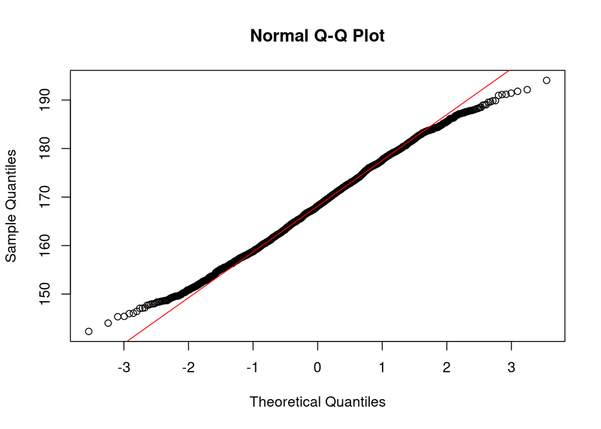

```r
qqnorm(sample.info.pcs$height)
qqline(sample.info.pcs$height, col="red")
```

```r
#Part3 Qn4 : What covariates are included in the null model? (Hint: think back to your findings in part 0 and part 2.)
#Ans: Covariates that should be included in null model are sex, population(pop), PC1, PC2, PC3 and PC4.
```

## Part 4 - Association Test

Now, you will finally run the genotype association tests for the GWAS. The imputed genotypes are available as a SNP GDS file, `p3_imputed_data.gds`. Using this and the null model you created in Part 3, run the single variant association tests genome-wide using an additive genetic model. **You will need to EDIT code to achieve this and turn `eval=TRUE` in this chunk. To get this to run in RStudio make sure you leave the BPPARAM option as `BPPARAM=BiocParallel::SerialParam()`.**

```r
# read in GDS file
gdsfile <- paste0(my_folder, "p3_imputed_data.gds")

# create genotype data object
geno <- GdsGenotypeReader(filename = gdsfile)
genoData <- GenotypeData(geno)
genoData
```

```
## An object of class GenotypeData
##  | data:
## File: /ix1/hugen2072-2025s/p3/p3_imputed_data.gds (28.3M)
## +    [  ] *
## |--+ sample.id   { Str8 2548 LZMA_ra(7.84%), 1.6K }
## |--+ snp.id   { Int32 647629 LZMA_ra(6.24%), 157.9K }
## |--+ snp.rs.id   { Str8 647629 LZMA_ra(36.2%), 2.3M }
## |--+ snp.position   { Int32 647629 LZMA_ra(48.6%), 1.2M }
## |--+ snp.chromosome   { Str8 647629 LZMA_ra(0.03%), 489B }
## |--+ snp.allele   { Str8 647629 LZMA_ra(18.1%), 526.3K }
## \--+ genotype   { Bit2 2548x647629 LZMA_ra(6.12%), 24.1M } *
##  | SNP Annotation:
## NULL
##  | Scan Annotation:
## NULL
```

```r
# create the genotype block iterator
iterator <- GenotypeBlockIterator(genoData, snpBlock=5000, snpInclude=snps.keep)

# run association test
#  REPLACE your_null_model WITH YOUR NULL MODEL OBJECT FROM PART 3
assoc <- assocTestSingle(iterator,
                         null.model = null_model,
                         BPPARAM=BiocParallel::SerialParam())
```

```
## Using 1 CPU cores
```